# ZEAL CUCBA DTS (short-day) — R/qtl (bcsft) additive QTL on the TeoNAM JLM grid

- Show All Code
- Hide All Code
- View Source

Classic R/qtl interval mapping (Haley–Knott) of days-to-silking measured at CUCBA, Guadalajara (subtropical, short-day; ~20.7°N), on the BC2S3 rtiger ancestry mosaic (B73=A / het=H / teosinte=B). Same marker set + genetic map as the Clayton DTS notebook (TeoNAM JLM 0.1-cM, 9,063 markers). Significance = genome-wide 1000-permutation LOD threshold; models: no covariate vs + taxon (5-family), plus per-family scans.

Author

Fausto Rodríguez-Zapata

Published

August 10, 2026

**What this is.** The R/qtl additive scan of ZEAL flowering time (DTS = days to silking) measured at **CUCBA in Guadalajara** — the *short-day, subtropical* environment — as the short-day counterpart to the Clayton (long-day) `zeal-rqtl-dts-lod-profile` notebook. Same `bcsft` cross, TeoNAM JLM map, Haley–Knott interval mapping, **1000-permutation** threshold. Inputs: CUCBA BLUEs from `scripts/zeal_cucba_pheno.R`, scanned by `scripts/zeal_rqtl_scan.R` (`TRAIT=CUCBADTS`).

**ImportantRead this first — what is (and isn’t) solid here**

- **Environment = CUCBA only.** The *La Soledad* flowering columns equal CUCBA minus a constant 3 days (slope 1, R² ≈ 1), carrying no independent signal, so only **CUCBA** is usable short-day flowering (copy vs planting-date artifact undetermined). It is one **unreplicated augmented** environment (each NIL in one incomplete block; only the 3 checks replicated), so a BLUE is a block-adjusted single observation — no within-line error.
- **Provisional line join.** CUCBA is keyed by `Origen` (BZeaPV23-…); the map to the BC2S3 pedigree is the Genealogía crosswalk, pending the definitive three-way sample sheet.
- Marker set, map, and genotype identical to the Clayton DTS notebook: no ZEAL map is estimated (cM = TeoNAM distances); the ZEAL mosaic is projected onto the JLM positions; genotype = ancestry `A/H/B`; the permutation calibrates the threshold to the structured null.

```r
library(here)
library(data.table)
library(qtl)
library(ggplot2)
library(ggrepel)
RQ <- here("results/sim/zeal/rqtl")
stopifnot(dir.exists(RQ)) # run: Rscript scripts/zeal_cucba_pheno.R ; TRAITS="CUCBADTA,CUCBADTS" NPERM=1000 Rscript scripts/zeal_rqtl_scan.R

TRAIT <- "CUCBADTS"
trait_lc <- tolower(TRAIT)
bp_of <- function(m) as.integer(sub("^S[0-9]+_", "", m))
ci_str <- function(lbp, hbp) sprintf("%.1f–%.1f", pmin(lbp, hbp) / 1e6, pmax(lbp, hbp) / 1e6)

cand <- fread(here("data/teonam/dts_candidate_genes.tsv"))
cand[, mid := (start + end) / 2]
.nat <- fread(here("data/teonam/teonam_v5_native.tsv"))
cand[, cm := mapply(function(c, b) {
  n <- .nat[chr_v5 == c & is.finite(cm)][order(pos_v5)]
  if (nrow(n) < 2) NA_real_ else approx(n$pos_v5, n$cm, xout = b, rule = 2)$y
}, chr, mid)]
cand_in_ci <- function(ch, lo, hi) {
  s <- cand[chr == ch & mid >= min(lo, hi) & mid <= max(lo, hi), symbol]
  if (length(s)) paste(s, collapse = ", ") else "–"
}

load_scan <- function(tag) {
  one <- fread(file.path(RQ, sprintf("zeal_%s_scanone_%s.csv", trait_lc, tag)))
  perms <- readRDS(file.path(RQ, sprintf("zeal_%s_perms_%s.rds", trait_lc, tag)))
  th <- summary(perms, alpha = c(0.05, 0.10))
  list(one = one, thr5 = as.numeric(th[1]), thr10 = as.numeric(th[2]))
}
nc <- load_scan("nocovar")
tx <- load_scan("taxon")
cross <- readRDS(file.path(RQ, sprintf("zeal_%s_cross.rds", trait_lc)))
NMARK <- totmar(cross)
```

```r
g <- pull.geno(cross)
fH <- mean(g == 2, na.rm = TRUE)
fB <- mean(g == 3, na.rm = TRUE)
meta <- data.table(
  metric = c("individuals (CUCBA DTS)", "markers (TeoNAM JLM grid)", "chromosomes", "H / het", "B / teosinte", "H:B ratio"),
  value = c(
    sum(!is.na(pull.pheno(cross, TRAIT))), NMARK, nchr(cross),
    sprintf("%.3f", fH), sprintf("%.3f", fB), sprintf("%.1f", fH / fB)
  )
)
knitr::kable(meta, caption = "Run composition. Individuals = BC2S3 lines with a CUCBA DTS BLUE (provisional join). Markers = the TeoNAM JLM 0.1-cM grid.")
```

Run composition. Individuals = BC2S3 lines with a CUCBA DTS BLUE (provisional join). Markers = the TeoNAM JLM 0.1-cM grid.

| metric | value |
| --- | --- |
| individuals (CUCBA DTS) | 936 |
| markers (TeoNAM JLM grid) | 9063 |
| chromosomes | 10 |
| H / het | 0.090 |
| B / teosinte | 0.020 |
| H:B ratio | 4.5 |

## No covariate vs taxon covariate

```r
peakrow <- function(tag) {
  pk <- fread(file.path(RQ, sprintf("zeal_%s_peaks_%s.csv", trait_lc, tag)))
  setnames(pk, old = names(pk), new = sub("^lod\\.", "", names(pk)))
  pk
}
cmp <- data.table(
  model = c("no covariate", "+ taxon (5-family)"),
  `perm 5% LOD` = round(c(nc$thr5, tx$thr5), 2),
  `perm 10% LOD` = round(c(nc$thr10, tx$thr10), 2),
  `max LOD` = round(c(max(nc$one$lod), max(tx$one$lod)), 2),
  `n QTL (FWER 0.05)` = c(nrow(peakrow("nocovar")), nrow(peakrow("taxon")))
)
knitr::kable(cmp, caption = "CUCBA short-day DTS: permutation thresholds and QTL counts, no covariate vs the 5-family taxon covariate.")
```

CUCBA short-day DTS: permutation thresholds and QTL counts, no covariate vs the 5-family taxon covariate.

| model | perm 5% LOD | perm 10% LOD | max LOD | n QTL (FWER 0.05) |
| --- | --- | --- | --- | --- |
| no covariate | 4.72 | 4.31 | 9.93 | 1 |
| + taxon (5-family) | 4.54 | 4.19 | 9.98 | 1 |

## Genome-wide LOD profile (taxon model, with no-covariate behind it)

Faceted by chromosome. **Blue** = scanone + taxon; **grey** = no covariate; dashed = 1000-perm 5% thresholds; dotted verticals = flowering candidates; red points = per-chromosome maxima above the taxon 5% threshold.

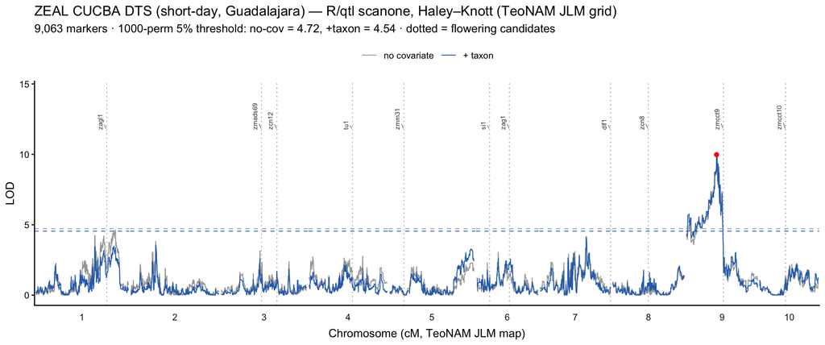

```r
prof <- rbindlist(list(
  cbind(nc$one[, .(marker, chr, pos, lod)], model = "no covariate"),
  cbind(tx$one[, .(marker, chr, pos, lod)], model = "+ taxon")
))[is.finite(lod)]
prof[, model := factor(model, levels = c("no covariate", "+ taxon"))]
sig <- prof[model == "+ taxon" & lod >= tx$thr5][, .SD[which.max(lod)], by = chr]
pal <- c("no covariate" = "grey65", "+ taxon" = "#2c6fbb")
ytop <- max(prof$lod, na.rm = TRUE)
cl <- cand[chr %in% unique(prof$chr) & is.finite(cm)]
p <- ggplot(prof, aes(pos, lod, colour = model)) +
  geom_vline(data = cl, aes(xintercept = cm), inherit.aes = FALSE, linetype = "dotted", colour = "grey55", linewidth = 0.3) +
  geom_line(linewidth = 0.4) +
  geom_hline(yintercept = nc$thr5, linetype = "dashed", colour = pal[["no covariate"]], linewidth = 0.35) +
  geom_hline(yintercept = tx$thr5, linetype = "dashed", colour = pal[["+ taxon"]], linewidth = 0.35) +
  geom_point(data = sig, colour = "red", size = 1.6) +
  ggrepel::geom_text_repel(
    data = cl, aes(x = cm, y = ytop * 1.18, label = symbol), inherit.aes = FALSE,
    size = 2.2, colour = "grey25", angle = 90, hjust = 0, direction = "x", segment.size = 0.2, min.segment.length = 0
  ) +
  expand_limits(y = ytop * 1.45) +
  facet_grid(~chr, scales = "free_x", space = "free_x", switch = "x") +
  scale_colour_manual(values = pal, name = NULL) +
  labs(
    x = "Chromosome (cM, TeoNAM JLM map)", y = "LOD",
    title = "ZEAL CUCBA DTS (short-day, Guadalajara) — R/qtl scanone, Haley–Knott (TeoNAM JLM grid)",
    subtitle = sprintf(
      "%s markers · 1000-perm 5%% threshold: no-cov = %.2f, +taxon = %.2f · dotted = flowering candidates",
      format(NMARK, big.mark = ","), nc$thr5, tx$thr5
    )
  ) +
  theme_classic(base_size = 11) +
  theme(
    axis.text.x = element_blank(), axis.ticks.x = element_blank(),
    panel.spacing = unit(0.05, "lines"), strip.placement = "outside",
    strip.background = element_blank(), legend.position = "top"
  ) +
  scale_x_continuous(expand = c(0.01, 0))
ggsave(file.path(RQ, sprintf("zeal_%s_lod_profile.png", trait_lc)), p, width = 11, height = 4.4, dpi = 200, bg = "white")
p
```

## Significant peaks (taxon model, α = 0.05)

```r
cipk <- fread(file.path(RQ, sprintf("zeal_%s_peaks_ci_taxon.csv", trait_lc)))
if (nrow(cipk) == 0) {
  cat("No chromosome exceeded the taxon-model 1000-perm 5% threshold.")
} else {
  knitr::kable(
    cipk[order(chr, -lod), .(
      chr,
      `pos (cM)` = round(pos, 1), `pos (Mb)` = round(bp_of(marker) / 1e6, 1),
      LOD = round(lod, 2), pval, marker,
      `1.5-LOD CI (Mb)` = ci_str(ci_left, ci_right),
      `candidate in CI` = mapply(cand_in_ci, chr, ci_left, ci_right)
    )],
    caption = "Genome-wide significant CUCBA-DTS QTL, taxon model (1000-perm threshold). One peak per chromosome; 1.5-LOD interval in v5 Mb; flowering candidate in CI."
  )
}
```

Genome-wide significant CUCBA-DTS QTL, taxon model (1000-perm threshold). One peak per chromosome; 1.5-LOD interval in v5 Mb; flowering candidate in CI.

| chr | pos (cM) | pos (Mb) | LOD | pval | marker | 1.5-LOD CI (Mb) | candidate in CI |
| --- | --- | --- | --- | --- | --- | --- | --- |
| 9 | 61.8 | 37.2 | 9.98 | 0 | S9_37177549 | 28.5–94.3 | – |

### Multi-peak refinement (airmine `refine_peaks`)

```r
rt <- fread(file.path(RQ, sprintf("zeal_%s_peaks_refined_taxon.csv", trait_lc)))
if (nrow(rt) == 0) {
  cat("No refined peaks (no chromosome exceeded the permutation threshold).")
} else {
  knitr::kable(
    rt[order(chr, -lod), .(
      chr,
      `pos (cM)` = round(pos, 1), `pos (Mb)` = round(bp_of(marker) / 1e6, 1),
      LOD = round(lod, 2), `perm 5% thr` = round(thresh, 2), marker,
      `1.5-LOD CI (Mb)` = ci_str(ci_left, ci_right),
      `candidate in CI` = mapply(cand_in_ci, chr, ci_left, ci_right)
    )],
    caption = sprintf("Refined multi-peak CUCBA-DTS QTL, taxon model (%d QTL across %d chromosomes).", nrow(rt), uniqueN(rt$chr))
  )
}
```

Refined multi-peak CUCBA-DTS QTL, taxon model (1 QTL across 1 chromosomes).

| chr | pos (cM) | pos (Mb) | LOD | perm 5% thr | marker | 1.5-LOD CI (Mb) | candidate in CI |
| --- | --- | --- | --- | --- | --- | --- | --- |
| 9 | 61.8 | 37.2 | 9.98 | 4.54 | S9_37177549 | 28.5–94.3 | – |

## Per-taxon (family-resolved) additive scan

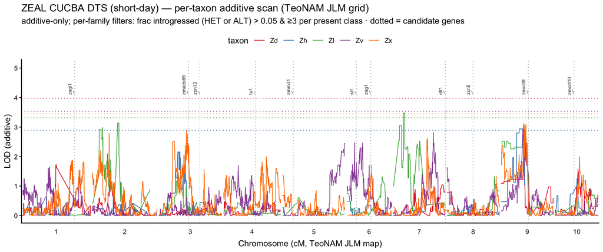

```r
bt <- fread(file.path(RQ, sprintf("zeal_%s_scanone_by_taxon.csv", trait_lc)))[is.finite(lod)]
pal5 <- c(Zd = "#E41A1C", Zh = "#377EB8", Zl = "#4DAF4A", Zv = "#984EA3", Zx = "#FF7F00")
ytop_bt <- max(bt$lod, na.rm = TRUE)
cl <- cand[chr %in% unique(bt$chr) & is.finite(cm)]
pt <- ggplot(bt, aes(pos, lod, colour = taxon)) +
  geom_vline(data = cl, aes(xintercept = cm), inherit.aes = FALSE, linetype = "dotted", colour = "grey55", linewidth = 0.3) +
  ggrepel::geom_text_repel(
    data = cl, aes(x = cm, y = ytop_bt * 1.18, label = symbol), inherit.aes = FALSE,
    size = 2.2, colour = "grey25", angle = 90, hjust = 0, direction = "x", segment.size = 0.2, min.segment.length = 0
  ) +
  expand_limits(y = ytop_bt * 1.45) +
  geom_line(linewidth = 0.4) +
  geom_hline(
    data = unique(bt[, .(taxon, thr5)]), aes(yintercept = thr5, colour = taxon),
    linetype = "dotted", linewidth = 0.4, show.legend = FALSE
  ) +
  facet_grid(~chr, scales = "free_x", space = "free_x", switch = "x") +
  scale_colour_manual(values = pal5, name = "taxon") +
  labs(
    x = "Chromosome (cM, TeoNAM JLM map)", y = "LOD (additive)",
    title = "ZEAL CUCBA DTS (short-day) — per-taxon additive scan (TeoNAM JLM grid)",
    subtitle = "additive-only; per-family filters: frac introgressed (HET or ALT) > 0.05 & ≥3 per present class · dotted = candidate genes"
  ) +
  theme_classic(base_size = 11) +
  theme(
    axis.text.x = element_blank(), axis.ticks.x = element_blank(),
    panel.spacing = unit(0.05, "lines"), strip.placement = "outside",
    strip.background = element_blank(), legend.position = "top"
  ) +
  scale_x_continuous(expand = c(0.01, 0))
ggsave(file.path(RQ, sprintf("zeal_%s_lod_by_taxon.png", trait_lc)), pt, width = 11, height = 4.6, dpi = 200, bg = "white")
pt
```

```r
btpk <- bt[,
  {
    i <- which.max(lod)
    ch <- chr[i]
    L <- lod[i]
    ins <- .SD[chr == ch][lod >= L - 1.5]
    lbp <- min(bp_of(ins$marker))
    hbp <- max(bp_of(ins$marker))
    .(
      chr = ch, `pos (cM)` = round(pos[i], 1), `pos (Mb)` = round(bp_of(marker[i]) / 1e6, 1),
      marker = marker[i], `max LOD` = round(L, 2), `perm 5% thr` = round(thr5[1], 2),
      sig = fifelse(L > thr5[1], "yes", "no"),
      `1.5-LOD CI (Mb)` = sprintf("%.1f–%.1f", lbp / 1e6, hbp / 1e6),
      `candidate in CI` = cand_in_ci(ch, lbp, hbp)
    )
  },
  by = taxon
][order(-`max LOD`)]
knitr::kable(btpk, caption = "Genome-wide additive peak per taxon for CUCBA DTS (filtered), with each family's own 1000-perm 5% threshold.")
```

Genome-wide additive peak per taxon for CUCBA DTS (filtered), with each family’s own 1000-perm 5% threshold.

| taxon | chr | pos (cM) | pos (Mb) | marker | max LOD | perm 5% thr | sig | 1.5-LOD CI (Mb) | candidate in CI |
| --- | --- | --- | --- | --- | --- | --- | --- | --- | --- |
| Zl | 7 | 29.4 | 7.1 | S7_7131441 | 3.48 | 3.32 | yes | 3.8–134.5 | – |
| Zx | 9 | 63.7 | 60.2 | S9_60173703 | 3.11 | 3.45 | no | 1.9–115.6 | – |
| Zh | 9 | 50.6 | 22.5 | S9_22452744 | 2.94 | 2.89 | yes | 13.7–79.8 | – |
| Zv | 9 | 60.7 | 31.7 | S9_31703477 | 2.93 | 3.53 | no | 19.8–118.7 | – |
| Zd | 1 | 95.0 | 197.5 | S1_197504766 | 1.72 | 3.97 | no | 8.0–306.7 | zagl1 |

```r
btr <- fread(file.path(RQ, sprintf("zeal_%s_peaks_refined_by_taxon.csv", trait_lc)))
if (nrow(btr) == 0) {
  cat("No per-taxon refined peaks cleared the per-family thresholds.")
} else {
  knitr::kable(
    btr[order(taxon, chr, -lod), .(
      taxon, chr,
      `pos (cM)` = round(pos, 1), `pos (Mb)` = round(bp_of(marker) / 1e6, 1),
      LOD = round(lod, 2), `perm 5% thr` = round(thr5, 2), marker,
      `1.5-LOD CI (Mb)` = ci_str(ci_left, ci_right),
      `candidate in CI` = mapply(cand_in_ci, chr, ci_left, ci_right)
    )],
    caption = sprintf("Refined per-taxon multi-peak CUCBA-DTS QTL (%d QTL across %d families), 1.5-LOD-drop CIs in v5 Mb.", nrow(btr), uniqueN(btr$taxon))
  )
}
```

Refined per-taxon multi-peak CUCBA-DTS QTL (2 QTL across 2 families), 1.5-LOD-drop CIs in v5 Mb.

| taxon | chr | pos (cM) | pos (Mb) | LOD | perm 5% thr | marker | 1.5-LOD CI (Mb) | candidate in CI |
| --- | --- | --- | --- | --- | --- | --- | --- | --- |
| Zh | 9 | 50.6 | 22.5 | 2.94 | 2.89 | S9_22452744 | 13.3–81.5 | – |
| Zl | 7 | 29.4 | 7.1 | 3.48 | 3.32 | S7_7131441 | 0.5–152.4 | – |

## Allele effect at the genome-wide peak, by taxon

The teosinte-allele effect on CUCBA DTS at the **strongest genome-wide (taxon-model) peak**, split by taxon (marker derived from the peaks table above). Mean ± SE drawn only for genotype classes with ≥ 3 lines; undersupported classes show raw points + count. `A/A` = B73, `A/B` = het, `B/B` = homozygous teosinte. Effect in **days**; LOD above is the support — read separately.

```r
.cipk <- fread(file.path(RQ, sprintf("zeal_%s_peaks_ci_taxon.csv", trait_lc)))
mk <- if (nrow(.cipk)) .cipk[which.max(lod), marker] else tx$one[which.max(lod), marker]
mk_chr <- tx$one[marker == mk, chr][1]
mk_mb <- round(bp_of(mk) / 1e6, 1)
```

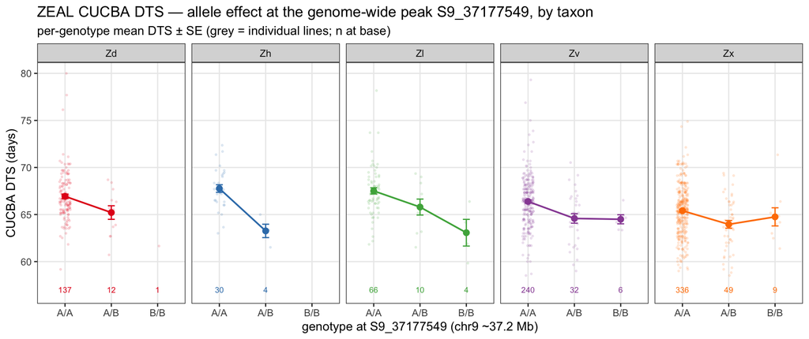

```r
pal5 <- c(Zd = "#E41A1C", Zh = "#377EB8", Zl = "#4DAF4A", Zv = "#984EA3", Zx = "#FF7F00")
gm <- pull.geno(cross)[, mk]
y <- as.numeric(pull.pheno(cross, TRAIT))
ids <- as.character(pull.pheno(cross, "id"))
ss <- fread(here("data/zeal/samplesheet_3way.csv"))[, .(pedigree, taxon)]
d <- data.table(
  taxon = ss[match(ids, pedigree), taxon],
  geno = factor(c("A/A", "A/B", "B/B")[gm], levels = c("A/A", "A/B", "B/B")), y
)[!is.na(y) & !is.na(geno) & taxon %in% c("Zd", "Zh", "Zl", "Zv", "Zx")]
summ <- d[, .(mean = mean(y), se = sd(y) / sqrt(.N), n = .N), by = .(taxon, geno)]
shown <- summ[n >= 3]
ef <- ggplot(d, aes(geno, y, colour = taxon)) +
  geom_jitter(width = 0.12, alpha = 0.12, size = 0.5) +
  geom_line(data = shown, aes(y = mean, group = taxon), linewidth = 0.7) +
  geom_point(data = shown, aes(y = mean), size = 2.2) +
  geom_errorbar(data = shown, aes(y = mean, ymin = mean - se, ymax = mean + se), width = 0.15) +
  geom_text(data = summ, aes(label = n), y = min(d$y), vjust = 0, size = 2.5, show.legend = FALSE) +
  facet_wrap(~taxon, nrow = 1) +
  scale_colour_manual(values = pal5, guide = "none") +
  labs(
    x = sprintf("genotype at %s (chr%s ~%s Mb)", mk, mk_chr, mk_mb), y = "CUCBA DTS (days)",
    title = sprintf("ZEAL CUCBA DTS — allele effect at the genome-wide peak %s, by taxon", mk),
    subtitle = "per-genotype mean DTS ± SE (grey = individual lines; n at base)"
  ) +
  theme_bw(base_size = 11) +
  theme(panel.grid.minor = element_blank())
ggsave(file.path(RQ, sprintf("zeal_%s_%s_effect.png", trait_lc, mk)), ef, width = 10, height = 4.2, dpi = 200, bg = "white")
ef
```

```r
eff <- dcast(summ, taxon ~ geno, value.var = "mean")
ns <- dcast(summ, taxon ~ geno, value.var = "n")
setnames(ns, names(ns)[-1], paste0("n ", names(ns)[-1]), skip_absent = TRUE)
knitr::kable(merge(eff, ns, by = "taxon"),
  digits = 1,
  caption = sprintf("Mean CUCBA DTS by genotype and taxon at %s (chr%s ~%s Mb), with cell counts.", mk, mk_chr, mk_mb)
)
```

Mean CUCBA DTS by genotype and taxon at S9_37177549 (chr9 ~37.2 Mb), with cell counts.

| taxon | A/A | A/B | B/B | n A/A | n A/B | n B/B |
| --- | --- | --- | --- | --- | --- | --- |
| Zd | 66.9 | 65.2 | 61.7 | 137 | 12 | 1 |
| Zh | 67.8 | 63.3 | NA | 30 | 4 | NA |
| Zl | 67.5 | 65.8 | 63.1 | 66 | 10 | 4 |
| Zv | 66.4 | 64.6 | 64.5 | 240 | 32 | 6 |
| Zx | 65.4 | 64.0 | 64.8 | 336 | 49 | 9 |

## Note

Short-day (CUCBA) additive silking scan; compare with the long-day Clayton DTS notebook, and see `zeal-rqtl-gxe-photoperiod` for the formal day-length (marker × macroenvironment) contrast. All CUCBA results are **provisional**: one unreplicated environment and a Genealogía-mapped line join, pending real La Soledad flowering and the definitive three-way sample sheet.